# ChallengeB

Tiphaine Gouraud & Nina RuliÃ©

# challenge-b-rprog-m1-eco

Github links: https://github.com/TiphaineGOU https://github.com/Ninarulie —

TASK 1B: Prediction House prices in Ames, Iowa

## Load datas and packages

```r
install.packages("tidyverse")
install.packages("readr")
install.packages("randomForest")
install.packages("np")
```

```r
library(randomForest)
library(tidyverse)
library(readr)
library(dplyr)
```

```r
train<- read_csv("train.csv")
Test<- read_csv(file = "test.csv")
```

# We choose a ML technique : randomForest

RandomForest is an algorithm which create forest with a number of trees, the more trees in the forest, the more robust is the model. RandomForest select randomly a number of features in from the total amount of features. It use these features randomly selected to find the root node. After that it calculate the daughter nodes and repeat this 3 steps until it has formed a tree with a root node and the target as a leaf. And it repeat this 4 steps until it has a n number of trees. When we train randomForest algorithm to perfom prediction, it takes the test features and use the rules of each randomly created decision tree to predict the out come. The final decision will be the target wich have been reach the most. RandomForest is used most of the time to make prediction when there is a big amount of variables. In the prediction we are going to do there are 74 variable, which is a lot this is why we think it is relevant to use it.

## Prepare the datas

```r
colnames(train)
```

```
##  [1] "Id"            "MSSubClass"    "MSZoning"      "LotFrontage"
##  [5] "LotArea"       "Street"        "Alley"         "LotShape"
##  [9] "LandContour"   "Utilities"     "LotConfig"     "LandSlope"
## [13] "Neighborhood"  "Condition1"    "Condition2"    "BldgType"
## [17] "HouseStyle"    "OverallQual"   "OverallCond"   "YearBuilt"
## [21] "YearRemodAdd"  "RoofStyle"     "RoofMatl"      "Exterior1st"
## [25] "Exterior2nd"   "MasVnrType"    "MasVnrArea"    "ExterQual"
## [29] "ExterCond"     "Foundation"    "BsmtQual"      "BsmtCond"
## [33] "BsmtExposure"  "BsmtFinType1"  "BsmtFinSF1"    "BsmtFinType2"
## [37] "BsmtFinSF2"    "BsmtUnfSF"     "TotalBsmtSF"   "Heating"
## [41] "HeatingQC"     "CentralAir"    "Electrical"    "1stFlrSF"
## [45] "2ndFlrSF"      "LowQualFinSF"  "GrLivArea"     "BsmtFullBath"
## [49] "BsmtHalfBath"  "FullBath"      "HalfBath"      "BedroomAbvGr"
## [53] "KitchenAbvGr"  "KitchenQual"   "TotRmsAbvGrd"  "Functional"
## [57] "Fireplaces"    "FireplaceQu"   "GarageType"    "GarageYrBlt"
## [61] "GarageFinish"  "GarageCars"    "GarageArea"    "GarageQual"
## [65] "GarageCond"    "PavedDrive"    "WoodDeckSF"    "OpenPorchSF"
## [69] "EnclosedPorch" "3SsnPorch"     "ScreenPorch"   "PoolArea"
## [73] "PoolQC"        "Fence"         "MiscFeature"   "MiscVal"
## [77] "MoSold"        "YrSold"        "SaleType"      "SaleCondition"
## [81] "SalePrice"
```

```r
Train2<-train[-1]
```

We remove id column : no pertinence in the model.

```r
remove.vars <- Train2 %>% summarise_all(.funs = funs(sum(is.na(.)))) %>% gather(key = "feature", value = "missing.observations") %>% filter(missing.observations > 100) %>% select(feature) %>% unlist
Train2 <- Train2 %>% select(- one_of(remove.vars))
```

We remove variables with a lot of missing observations (as we learned is ChallengeA)

```r
Train2 %>% summarise_all(.funs = funs(sum(is.na(.)))) %>% gather(key = "feature", value = "missing.observations") %>% filter(missing.observations > 0)
```

```
## # A tibble: 13 x 2
##         feature missing.observations
##           <chr>                <int>
##  1   MasVnrType                    8
##  2   MasVnrArea                    8
##  3     BsmtQual                   37
##  4     BsmtCond                   37
##  5 BsmtExposure                   38
##  6 BsmtFinType1                   37
##  7 BsmtFinType2                   38
##  8   Electrical                    1
##  9   GarageType                   81
## 10  GarageYrBlt                   81
## 11 GarageFinish                   81
## 12   GarageQual                   81
## 13   GarageCond                   81
```

```r
Train2 <-Train2 %>% filter(is.na(GarageType) == FALSE, is.na(MasVnrType) == FALSE, is.na(BsmtFinType2) == FALSE, is.na(BsmtExposure) == FALSE, is.na(Electrical) == FALSE)
```

We remove missing observations from the data base.

```r
Train3 <-Train2%>%mutate_if(is.character,as.factor)
```

We convert characters to factors.

```r
names(Train3)<-make.names(names(Train3))
```

We do this to make sure, the names of the colomnes are the one we can see.

## Random Forest Model

```r
set.seed(1)
Train.fit<-randomForest(Train3$SalePrice~., data=Train3)
```

We train the chosen technique on the training data here, Random Forest.

## Prediction on test data

```r
Predict.RandomForest<-predict(Train.fit,data=Test)
```

We now have prediction on the data set with RandomForest.

```r
Train.lm<-lm(data=Train3,SalePrice~.)
print.lm<-print(Train.lm)
```

```
##
## Call:
## lm(formula = SalePrice ~ ., data = Train3)
##
## Coefficients:
##          (Intercept)            MSSubClass            MSZoningFV
##           -9.910e+05            -4.293e+01             4.160e+04
##           MSZoningRH            MSZoningRL            MSZoningRM
##            3.026e+04             3.227e+04             2.842e+04
##              LotArea            StreetPave           LotShapeIR2
##            8.118e-01             4.858e+04             3.185e+03
##          LotShapeIR3           LotShapeReg        LandContourHLS
##            1.548e+03             1.398e+03             9.134e+03
##       LandContourLow        LandContourLvl       UtilitiesNoSeWa
##           -1.256e+04             5.057e+03            -3.620e+04
##     LotConfigCulDSac          LotConfigFR2          LotConfigFR3
##            7.647e+03            -9.540e+03            -1.476e+04
##      LotConfigInside          LandSlopeMod          LandSlopeSev
##           -1.670e+03             6.331e+03            -4.566e+04
##  NeighborhoodBlueste    NeighborhoodBrDale   NeighborhoodBrkSide
##            3.786e+02             1.191e+03            -1.710e+03
##  NeighborhoodClearCr   NeighborhoodCollgCr   NeighborhoodCrawfor
##           -1.393e+04            -1.007e+04             1.144e+04
##  NeighborhoodEdwards   NeighborhoodGilbert    NeighborhoodIDOTRR
##           -2.265e+04            -1.081e+04            -4.692e+03
##  NeighborhoodMeadowV   NeighborhoodMitchel     NeighborhoodNAmes
##           -9.086e+03            -1.972e+04            -1.848e+04
##  NeighborhoodNoRidge   NeighborhoodNPkVill   NeighborhoodNridgHt
##            2.406e+04             1.357e+04             1.711e+04
##   NeighborhoodNWAmes   NeighborhoodOldTown    NeighborhoodSawyer
##           -1.918e+04            -1.205e+04            -1.080e+04
##  NeighborhoodSawyerW   NeighborhoodSomerst   NeighborhoodStoneBr
##           -3.633e+03            -3.369e+03             3.609e+04
##    NeighborhoodSWISU    NeighborhoodTimber   NeighborhoodVeenker
##           -8.257e+03            -1.135e+04             1.437e+03
##      Condition1Feedr        Condition1Norm        Condition1PosA
##            3.919e+03             1.387e+04             5.976e+03
##       Condition1PosN        Condition1RRAe        Condition1RRAn
##            1.157e+04            -1.709e+04             9.009e+03
##       Condition1RRNe        Condition1RRNn       Condition2Feedr
```

[output cut: 102 more lines]

```
##            1.452e+03             1.258e+01             2.690e+00
##        EnclosedPorch            X3SsnPorch           ScreenPorch
##            1.063e+00             2.812e+01             2.756e+01
##             PoolArea               MiscVal                MoSold
##            8.115e+01             1.663e-01            -4.352e+02
##               YrSold           SaleTypeCon         SaleTypeConLD
##           -2.439e+02             2.686e+04             2.285e+04
##        SaleTypeConLI         SaleTypeConLw           SaleTypeCWD
##            1.660e+03            -1.717e+03             1.559e+04
##          SaleTypeNew           SaleTypeOth            SaleTypeWD
##            2.534e+04             2.629e+04            -2.116e+02
## SaleConditionAdjLand   SaleConditionAlloca   SaleConditionFamily
##            3.658e+04             9.237e+03            -1.385e+03
##  SaleConditionNormal  SaleConditionPartial
##            4.379e+03            -6.924e+03
```

```r
predict.lr<-predict(print.lm, data=Test)
```

Prediction with a a linear regression of our choice here Linear model of SalePrice on all the variables.

```r
summary(Predict.RandomForest)
```

```
##    Min. 1st Qu.  Median    Mean 3rd Qu.    Max.
##   85436  138265  170235  186349  217361  546554
```

```r
summary(predict.lr)
```

```
##    Min. 1st Qu.  Median    Mean 3rd Qu.    Max.
##   17911  133717  169868  186762  220056  640453
```

We use the summary of the prediction to compare the two models. Here we can see that the RandomForest prediction is more centred to the mean compare to the linear model prediction.

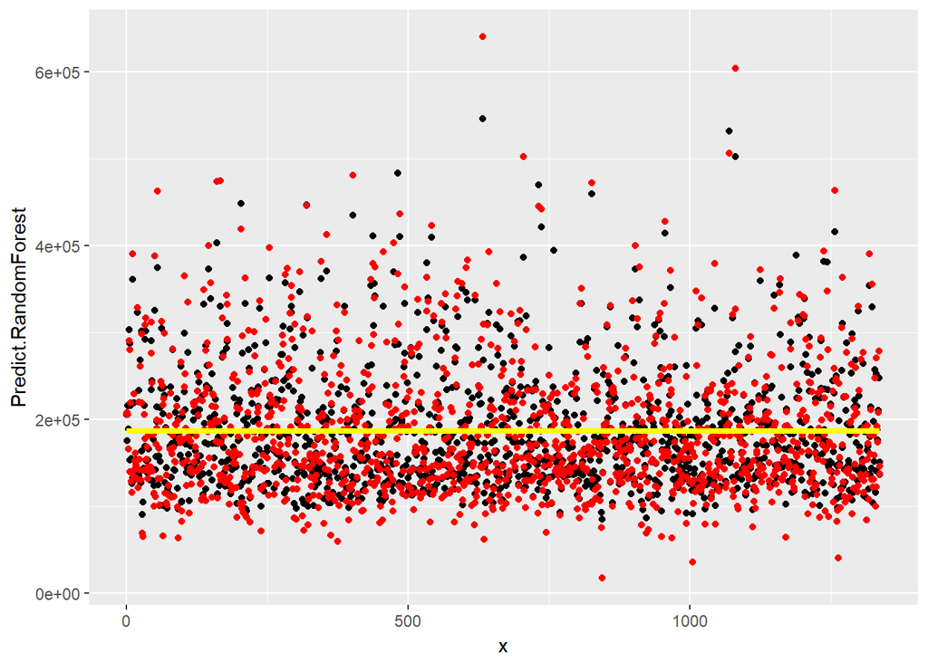

```r
x<-c(1:1338)
ggplot()+geom_point(aes(x,Predict.RandomForest))+geom_point(aes(x,predict.lr),col="red")+geom_line(aes(x,186500),col="yellow",size=1.5)
```

Black points are prediction with RandomForest, red point are prediction with Linear regression, the yellow line correspond approximatively to the mean. Here we can see once again that the RandomForest prediction is more centred to the mean compare to the linear model prediction.

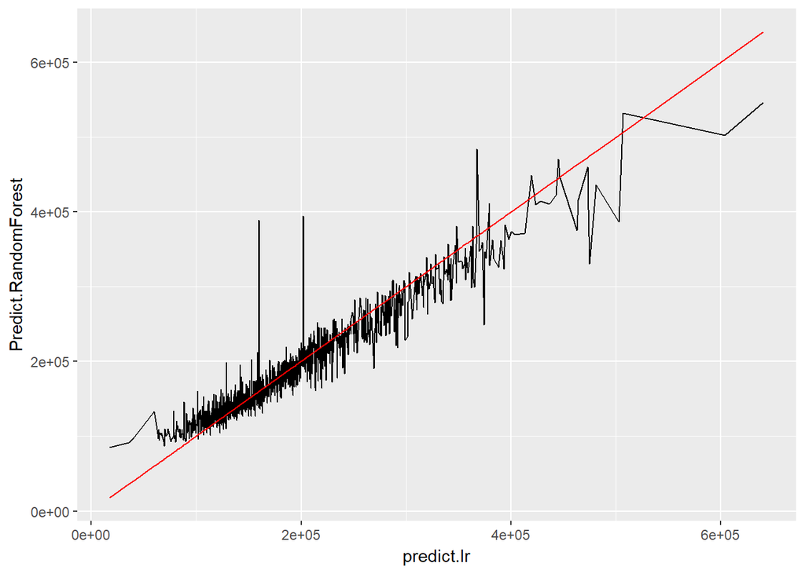

```r
ggplot()+geom_line(aes(predict.lr,Predict.RandomForest))+geom_line(aes(predict.lr,predict.lr),col="red")
```

Both model nevertheless are approximatively following the same trend, even if there is some extreme cases. The red line is the first bissector (x=x), we see that on average, the two model predict approximatively the same values.

# Task 2B: Overfitting in Machine Learning

## Challenge A dataset and packages we need

```r
# Packages
library(tidyverse)
library(caret)
library(np)
### Model : y = x^3+z , x and z normally distributed : mean = 0 and standard deviation = 1

set.seed(1)
Nsim <- 150
b <- c(0,1)
x0 <- rep(1, Nsim)
x1 <- rnorm(n = Nsim)

X <- cbind(x0, x1^3)
y.true <- X %*% b

eps <- rnorm(n = Nsim)
y <- X %*% b + eps

df <- tbl_df(y[,1]) %>% rename(y = value) %>% bind_cols(tbl_df(x1)) %>% rename(x = value) %>% bind_cols(tbl_df(y.true[,1])) %>% rename(y.true = value)

training.index <- createDataPartition(y = y, times = 1, p = 0.8)
df <- df %>% mutate(which.data = ifelse(1:n() %in% training.index$Resample1, "training", "test"))

training <- df %>% filter(which.data == "training")
test <- df %>% filter(which.data == "test")
lm.fit <- lm(y ~ x, data = training)
summary(lm.fit)
```

```
##
## Call:
## lm(formula = y ~ x, data = training)
##
## Residuals:
##     Min      1Q  Median      3Q     Max
## -4.7575 -1.0695  0.0419  1.0229  7.6216
##
## Coefficients:
##             Estimate Std. Error t value Pr(>|t|)
## (Intercept)   0.1950     0.1649   1.183    0.239
## x             2.4446     0.1846  13.241   <2e-16 ***
## ---
## Signif. codes:  0 '***' 0.001 '**' 0.01 '*' 0.05 '.' 0.1 ' ' 1
##
## Residual standard error: 1.82 on 120 degrees of freedom
## Multiple R-squared:  0.5937, Adjusted R-squared:  0.5903
## F-statistic: 175.3 on 1 and 120 DF,  p-value: < 2.2e-16
```

```r
df <- df %>% mutate(y.lm = predict(object = lm.fit, newdata = df))
training <- training %>% mutate(y.lm = predict(object = lm.fit))
```

We just copied and pasted what we did in the challenge A.

# Step 1

## Low-flexibility local linear model

```r
ll.fit.lowflex <- npreg(y ~ x, data = training, method = "ll", bws = 0.5)
summary(ll.fit.lowflex)
```

```
##
## Regression Data: 122 training points, in 1 variable(s)
##                 x
## Bandwidth(s): 0.5
##
## Kernel Regression Estimator: Local-Constant
## Bandwidth Type: Fixed
## Residual standard error: 1.442574
## R-squared: 0.8569977
##
## Continuous Kernel Type: Second-Order Gaussian
## No. Continuous Explanatory Vars.: 1
```

# Step 2

## High-flexibility Local model

```r
ll.fit.highflex<-npreg(y ~ x, data = training, method = "ll", bws = 0.01)
summary(ll.fit.highflex)
```

```
##
## Regression Data: 122 training points, in 1 variable(s)
##                  x
## Bandwidth(s): 0.01
##
## Kernel Regression Estimator: Local-Constant
## Bandwidth Type: Fixed
## Residual standard error: 0.5882872
## R-squared: 0.9569811
##
## Continuous Kernel Type: Second-Order Gaussian
## No. Continuous Explanatory Vars.: 1
```

# Step 3

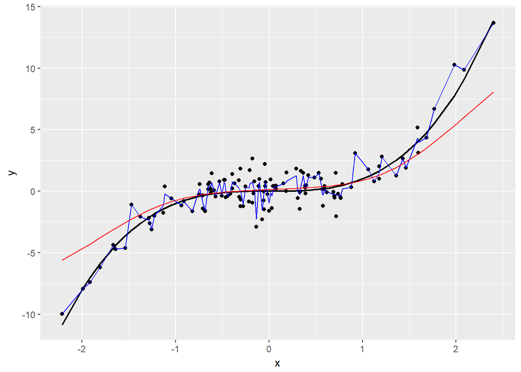

```r
y.high = predict(object = ll.fit.highflex, newdata = training)
y.low = predict(object = ll.fit.lowflex, newdata = training)

ggplot(training) + geom_point (data = training,aes(x,y)) + geom_line(aes(x,y.true), colour = "black", size = 0.8) + geom_line (mapping = aes(x = x, y = y.high), colour = "blue") + geom_line (mapping = aes(x = x, y = y.low), colour = "red")
```

Figure 1 task B : PRedictions of ll.fit.lowflex ans LL.fit.highflex on training data. We plot the tow models to compare them.

# Step 4

The high flexibility function has less bias, indeed it’s closer to the points : the obeservation. It’s also the prediction more variable, indeed it’s less mothy than the red ligne (low flexibility model) that is closer than the black ligne witch is the “true” model.

# Step 5

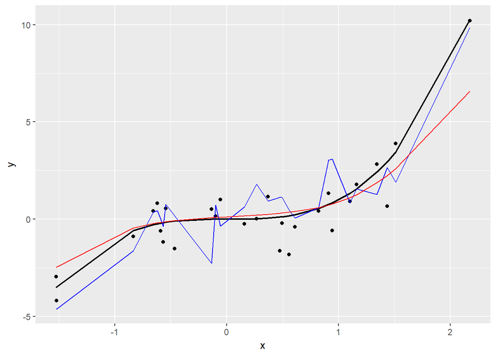

```r
##repete the same 3 first steps on testing

y.high.2 = predict(object = ll.fit.highflex, newdata = test)
y.low.2 = predict(object = ll.fit.lowflex, newdata = test)

ggplot(test) + geom_point (data = test,aes(x,y)) + geom_line(aes(x,y.true), colour = "black", size = 0.8) + geom_line (mapping = aes(x = x, y = y.high.2), colour = "blue") + geom_line (mapping = aes(x = x, y = y.low.2), colour = "red")
```

Figure 2 task B : PRedictions of ll.fit.lowflex ans LL.fit.highflex on test data.

We apply the model created on the testing data set.

# Step 6

```r
bw <- seq(0.01, 0.5, by = 0.001)
```

We create the vector of bandwidth.

# Step 7

## Local linear model on training data for different bandwidth.

```r
llestime<-lapply(X = bw, FUN = function(bw) {npreg(y ~ x, data = training, method = "ll", bws = bw)})
```

We estimate a local linear model y ~ x on the training data with each bandwidth. #Step 8

```r
mse.training <- function(fit.model){
  predictions <- predict(object = fit.model, newdata = training)
  training %>% mutate(squared.error = (y - predictions)^2) %>% summarize(mse = mean(squared.error))}
mse.train.results <- unlist(lapply(X = llestime, FUN = mse.training))
```

We compute for each bandwidth the MSE on the training data

# Step 9

```r
mse.testing <- function(fit.model){
  predictions <- predict(object = fit.model, newdata = test)
  test %>% mutate(squared.error = (y - predictions)^2) %>% summarize(mse = mean(squared.error))}
mse.test.results <- unlist(lapply(X = llestime, FUN = mse.testing))
```

We compute for each bandwidth the MSE on the test data.

# Step10

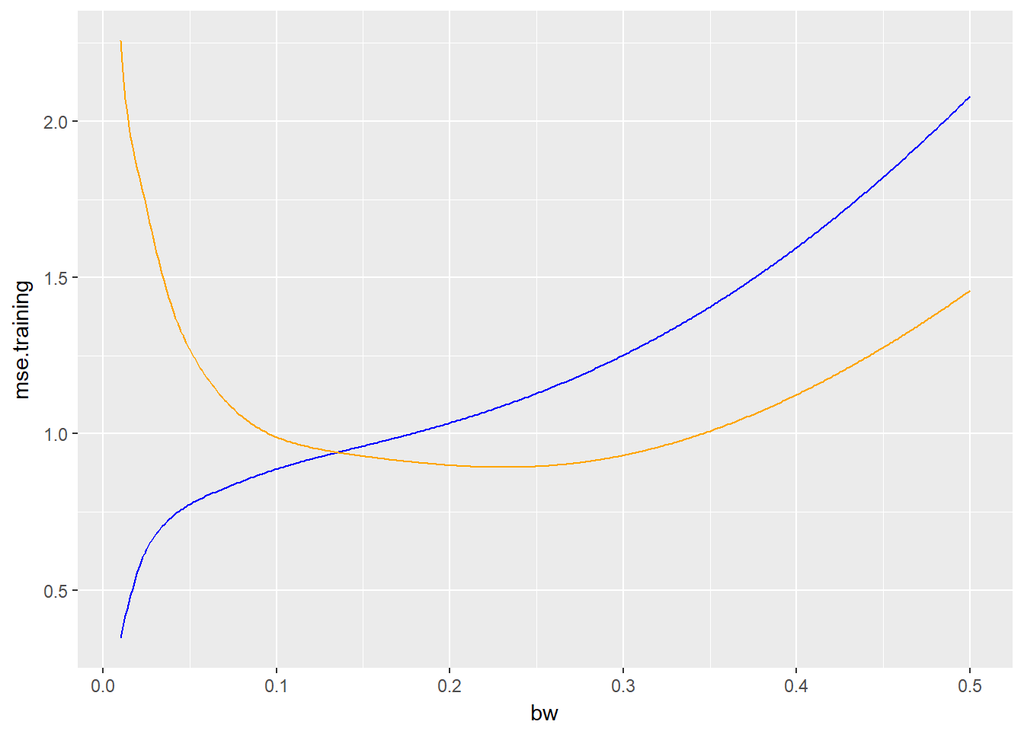

```r
mse.df <- tbl_df(data.frame(bandwidth = bw, mse.training = mse.train.results, mse.testing = mse.test.results))
ggplot(mse.df)+geom_line(mapping=aes(bw,mse.training),colour="blue")+geom_line(mapping=aes(bw,mse.testing),colour="orange")
```

Figure 3 task B : MSE on training and test data for differen bandwidth local linear regression.

TASK 3 : Privacy Regulation compliance in France ## /! It’s very long to run because we import and read the 2 entire files.

```r
library(readr)
library(readxl)
CNIL<- read_delim("OpenCNIL_Organismes_avec_CIL_VD_20171204.csv",  ";", escape_double = FALSE, trim_ws = TRUE)
SIRENE<- read_delim("rprog/sirc-17804_9075_14211_2017340_E_Q_20171207_022339046.csv", ";", escape_double = FALSE, trim_ws = TRUE)
### have to be change by
## SIREN<-('sirc-17804_9075_14209_201710_L_M_20171101_030132835.csv')
## just too long to run
```

```r
colnames(CNIL)
```

```
## [1] "Siren"       "Responsable" "Adresse"     "Code_Postal" "Ville"
## [6] "NAF"         "TypeCIL"     "Portee"
```

```r
colnames(CNIL)[colnames(CNIL)=="Siren"] <- "SIREN"
View(CNIL)
```

```r
cnil2 <- subset(CNIL, nchar(CNIL$Code_Postal) > 4,)
# Selecting the postal codes longer than 4 and placing them into cnil2
cnil3 <- subset(cnil2, nchar(cnil2$Code_Postal) < 6,)
# Among cnil2, selecting the postal codes smaller than 6: now, cnil3 contains only the correct postal codes with 5 numbers

cp <- sub ("^(\\d{2}).*$", "\\1", cnil3$Code_Postal);cp2 <- subset(cp, nchar(cp) < 3,)
# Creating a dataframe which contains only the 2 first numbers of the postal codes

nicetable<-data.frame(table(unlist(cp2)))
# Creating the nice table containing the number of organizations per department
colnames(nicetable)[colnames(nicetable)=="Var1"] <- "Departement";colnames(nicetable)[colnames(nicetable)=="Freq"] <- "Number of organizations"
print(nicetable)
```

```
##    Departement Number of organizations
## 1           01                     135
## 2           02                     105
## 3           03                      71
## 4           04                      74
## 5           05                      54
## 6           06                     257
## 7           07                      61
## 8           08                      82
## 9           09                      21
## 10          10                     102
## 11          11                      93
## 12          12                      89
## 13          13                     471
## 14          14                     258
```

[output cut: 83 more lines]

```r
View(nicetable)
```

```r
Merge<-merge(CNIL,SIRENE, by="SIREN")

colnames(Merge)
```

```
##   [1] "SIREN"         "Responsable"   "Adresse"       "Code_Postal"
##   [5] "Ville"         "NAF"           "TypeCIL"       "Portee"
##   [9] "NIC"           "L1_NORMALISEE" "L2_NORMALISEE" "L3_NORMALISEE"
##  [13] "L4_NORMALISEE" "L5_NORMALISEE" "L6_NORMALISEE" "L7_NORMALISEE"
##  [17] "L1_DECLAREE"   "L2_DECLAREE"   "L3_DECLAREE"   "L4_DECLAREE"
##  [21] "L5_DECLAREE"   "L6_DECLAREE"   "L7_DECLAREE"   "NUMVOIE"
##  [25] "INDREP"        "TYPVOIE"       "LIBVOIE"       "CODPOS"
##  [29] "CEDEX"         "RPET"          "LIBREG"        "DEPET"
##  [33] "ARRONET"       "CTONET"        "COMET"         "LIBCOM"
##  [37] "DU"            "TU"            "UU"            "EPCI"
##  [41] "TCD"           "ZEMET"         "SIEGE"         "ENSEIGNE"
##  [45] "IND_PUBLIPO"   "DIFFCOM"       "AMINTRET"      "NATETAB"
##  [49] "LIBNATETAB"    "APET700"       "LIBAPET"       "DAPET"
##  [53] "TEFET"         "LIBTEFET"      "EFETCENT"      "DEFET"
##  [57] "ORIGINE"       "DCRET"         "DDEBACT"       "ACTIVNAT"
```

[output cut: 17 more lines]

We merged the two table into one : adding info about companies identified by “SIREN” from one data set into the other.

```r
summary(Merge$TEFEN)
```

```
##    Length     Class      Mode
##       151 character character
```

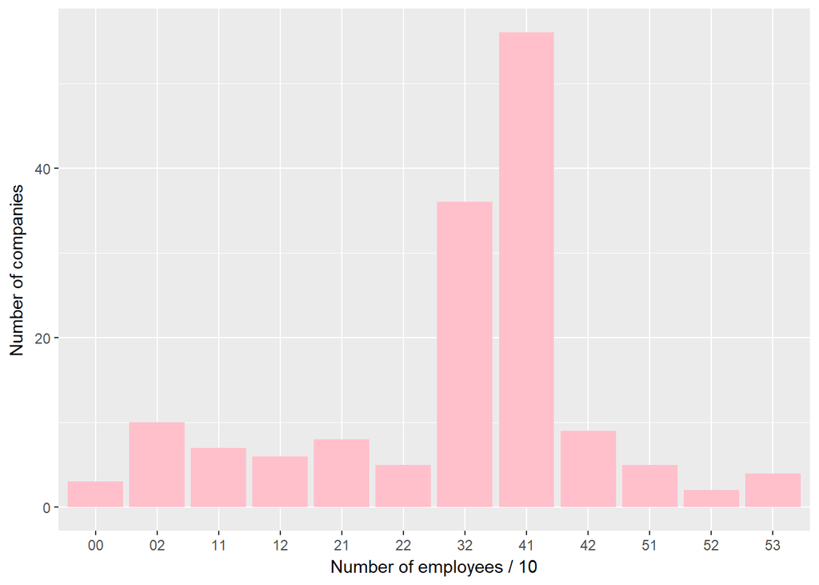

```r
MergeFactor <- as.factor(Merge$TEFEN)

ggplot(Merge) + geom_histogram(aes(TEFEN), stat="count",fill="pink") + ylab("Number of companies") + xlab("Number of employees / 10")
```

You an see a cute pink histogram of the size of the companies that nominated a CIL (/10). We notice that middle size companies that are the most nominating CIL.